# LEED Projects Analysys

Askka

2018-8-3

由美国绿色建筑协会(USGBC：U.S. Green Building Council)建立并推行的《绿色建筑评估体系》**LEED**(Leadership in Energy and Environmental Design)认证，被认为是是目前在世界各国的各类建筑环保评估、绿色建筑评估以及建筑可持续性评估标准中最完善、最有影响力的评估标准。自1998年推出LEED 1.0版本的试验性计划（Pilot Program）至今，全世界范围内已有167个国家和地区的近7万个项目取得LEED认证。

### 数据获取

从[USGBC网站](https://www.usgbc.org/sites/default/files/data/PublicLEEDProjectDirectory.xls)下载LEED认证项目数据库。源文件为xls格式，将其另存为CSV格式后导入R。该网站同样可下载[简版表格](https://www.usgbc.org/export-projects?download%20=%201&eid%20=%20528642)，简版表格中有“path”字段列出了每个项目的链接网址，后续可用网络爬虫来获取进一步信息加以分析时可以用到。

查看源数据表格可知，截至2018年6月6日，USGBC网站提供的LEEDS项目列表共有134367条数据。表格中提供了包括项目名称“ProjectName”、国家“Country”、认证类型“LEEDSystemVersionDisplayName”、认证等级“CertLevel”等在内的共19个字段的信息。

### 数据整理

#### 修改列名并调整显示顺序

从列出的表头信息判断，拟做下列调整：  
* 原文件中列名太长嫌繁琐，如“LEEDSystemVersionDisplayName”，考虑直接改为“Version”即可。  
* 为后续方便计，将所有列名改为小写。  
表中的字段除“ID”以外的各列可分为以下几类：  
1. 项目地理信息(“ProjectName”, “Street”, “City”, “State”, “Country”, “Zipcode”)  
2. 项目认证信息(“Certified”, “Version”, “Points”, “CertLevel”, “CertDate”)  
3. 项目物业资产信息(“confidential”, “OwnerTypes”, “GrossSqFoot”, “TotalArea”, “ProjectTypes”, “ORG”, “RegDate”)  
其中**认证信息**是我们最为关心的，将其调整至最前排列。而对于其中项目的具体地址(“Street”)、业主单位的性质(“OwnerTypes”)，包括项目ID等信息，并不是此次分析所关心的，因此全部调整至最后。调整顺序后，认证信息分布在(2:5)列；项目地理信息分布在(7:10)列；项目物业信息分布在(11:15)列；其它次要信息移至最后。其中，重点关注的LEED认证在各国的发展轨迹和接受程度。

#### 数据类型

- *id*、*points*、*grosssqFoot*、*totalarea*应为数值；*regdate*、*certdate*应为日期类型。  
- *Confidential*字段表示LEED项目是否要求信息保密，*Certified*字段表示LEED项目是否获得了相关认证。上述字段在原表中均以“Yes”和“No”字符串表示，除此之外的样本应为错误值。为便于后续统计分析，将**Confidential**、**Certified**字段为“Yes”则赋值为1，“No”为0。  
- *id*是所有项目的唯一标识码、*regdate*是项目在网上注册的日期。这两个字段应该不能出现NA缺失值。

#### 缺失值与错误值处理

利用VIM包中的aggr查看原始数据缺失值情况。

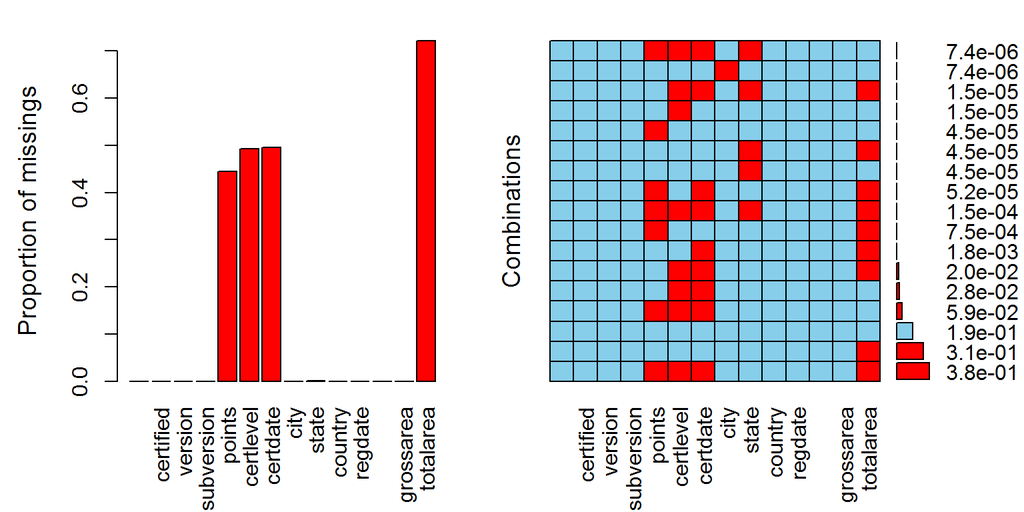

Aggregations for missing values

分析缺失值分布，缺失值主要在*point*、*certlevel*、*certdate*、以及*totalarea*字段，此外*projecttype*等字段同样有小部分缺失值。分析其缺失值产生原因，对于申请LEED认证但又没有最终通过的项目不存在认证日期、认证的等级等，判断项目认证信息的缺失值应该是由此而来。  
*totalarea*的缺失值，可能与各国各国对于建筑总面积“GFA：Gross floor area”的定义和具体统计范围规定不尽相同有关。由于LEED认证是采用申请单位在USGBC网站上填报提交项目有关信息，而USGBC更多的采用美国的习惯，如项目中的面积采用的是平方英尺(Squanl Foot)而非SI标准的平方米作为面积单位。因此判断面积数据的缺失值可能来自于提交，以及原始数据中录入等环节造成的误差。  
为验证上述分析，分析通过认证项目的缺失值分布，并忽略*totalarea*、*projecttype*等字段。

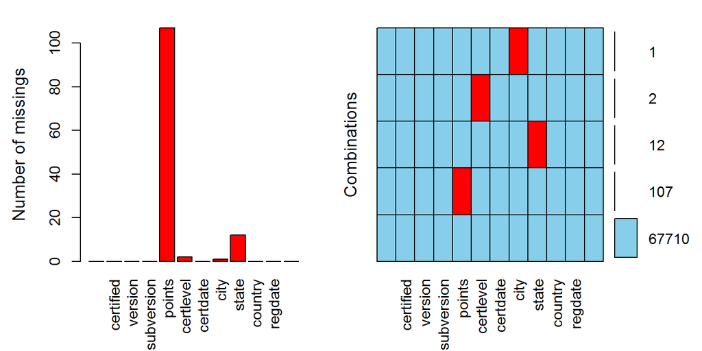

Missing values of certified LEED projects

由分析结果可知，取得了LEED认证的项目中，只有少数项目缺失州/省(**state**)、分数(**point**)等。按照LEED认证的规则，项目得分*point*只是作为评定最终LEED认证等级的依据，只要项目的*certlevel*数据真实有效，具体的分数多少并无更多的实际意义，因此对*point*缺失值拟不做处理，只在后续分析时以*certlevel*为主要的分类依据。而有意思的是缺失*state*数据的竟然多数集中为中国重庆的项目，占到了12个条目中的10个，剩下的两个为印度的项目。猜测可能与提交申请时只录入了*city*而未录入*stata*有关，不过如此不约而同也出乎意料之外。对上述条目，拟更正*state*信息后保留，最简单的方法便是采用*city*字段来作为*state*的值。

| projectname | certified | version | subversion | points | certlevel | certdate | city | state | country |
| --- | --- | --- | --- | --- | --- | --- | --- | --- | --- |
| Chongqing Hualongqiao B11-1/02 Phase I | 1 | v2 | LEED-CS 2.0 | 37 | Gold | 2015-03-22 | Chongqing | NA | CN |
| Nike CQ NB Store | 1 | v3 | LEED-CI Retail v2009 | 56 | Silver | 2017-02-03 | Chongqing | NA | CN |
| Deloitte Western Region Headquarter | 1 | v3 | LEED-CI v2009 | 44 | Certified | 2015-05-05 | Chongqing | NA | CN |
| Nu Skin Chongqing Image Store | 1 | v3 | LEED-CI v2009 | 62 | Gold | 2016-04-18 | Chongqing | NA | CN |
| Jones Lang LaSalle Chong Qing Office | 1 | v3 | LEED-CI v2009 | 62 | Gold | 2017-08-31 | Chong Qing | NA | CN |
| LFC–LIFAN CENTER | 1 | v3 | LEED-CS v2009 | 60 | Gold | 2015-03-26 | Chongqing | NA | CN |
| GUOHUA FINANCIAL CENTER | 1 | v3 | LEED-CS v2009 | 69 | Gold | 2017-09-08 | Chongqing | NA | CN |
| Chongqing Fortune Financial Center-FFC | 1 | v3 | LEED-CS v2009 | 64 | Gold | 2018-01-07 | Chongqing | NA | CN |
| VANA MALSI ESTATE | 1 | v3 | LEED-NC v2009 | 80 | Platinum | 2015-03-30 | DEHRADUN | NA | IN |
| Comprehensive Building of Dazhulin Depot | 1 | v3 | LEED-NC v2009 | 63 | Gold | 2015-05-18 | Chongqing | NA | CN |
| Manufacturing Facility | 1 | v3 | LEED-NC v2009 | 65 | Gold | 2015-07-15 | Roorkee | NA | IN |
| Balenciaga Chongqing MixC shop | 1 | v4 | LEED v4 ID+C: Retail | 63 | Gold | 2018-02-25 | Chongqing | NA | CN |

在前述*id*等字段的数据类型转换过程中提示了**NAs introduced by coercionNAs introduced by coercion**，亦即原始数据中有可能由于录入错误等造成的类型不符（如*id*不是纯数字、*regdate*不是日期格式）的数据被自动替换为了NA缺失值。这类数据极少，为简单计，直接舍去。

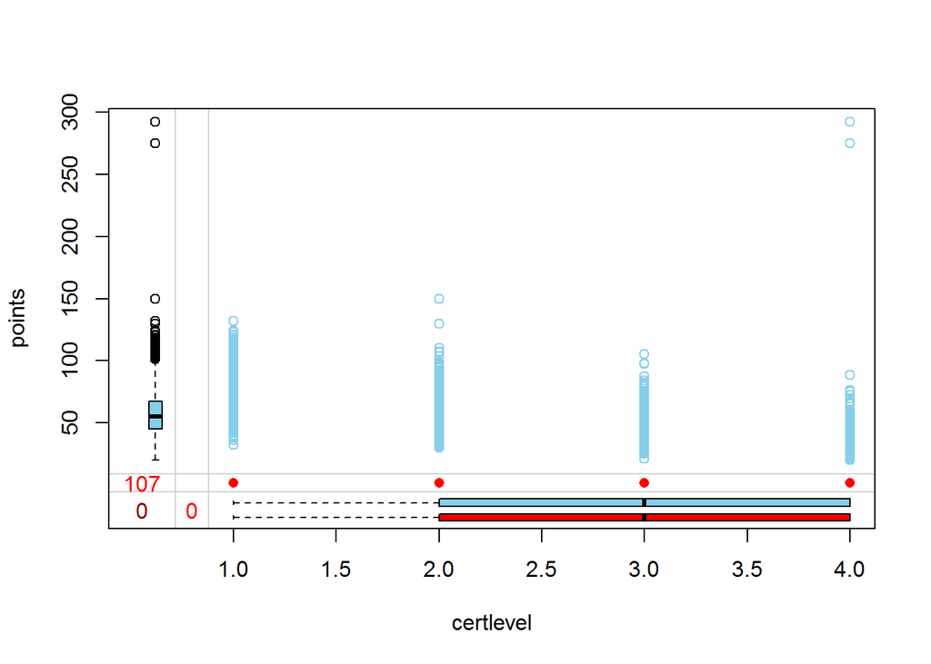

### 单变量分析

#### 认证项目分布

##### 认证信息是否公开

USGBC允许申请认证的项目可公开项目的具体地址、业主单位性质等信息。查看原表格可见，当*confidential*字段为1时，项目的部分信息，如项目名称、地址、邮编等可不公开，即原始数据中的*projectname*、*city*、*street*、*zipcode*、*org*、*ownertypes*只会显示为“Confidential”。这类数据共28467条，约占全部数据的21.19%。

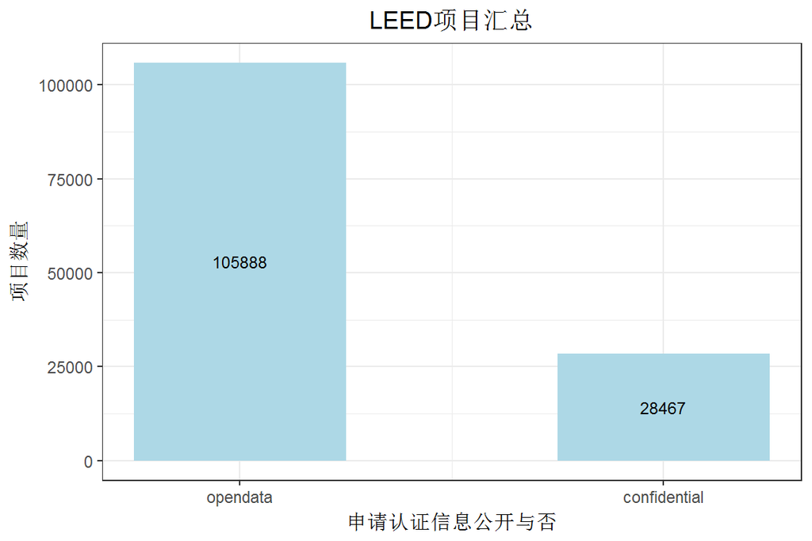

##### 认证项目等级

**Certlevel**是LEED认证项目所取得认证等级，可分为白金级（Platinum）、金级（Gold）、银级（Silver）、认证级（Certified）/青铜级（Bronze）共四个等级。“Bronez”认证等级只在早起的LEED认证测试（Pilot）版本中使用过，源数据中共4个项目是认证的此等级。为便于后续统计分析，将**Certlevel**字段空值（NA）全部改为**未认证（Uncertified）**，将**Bronez**统一为**Certified**并排序。  
源数据中未通过认证的项目的**certlevel**为空字段（NA），此外还有少部分（53个）条目此字段为**拒绝（Denied）**，怀疑是不符合LEED认证申请的前提条件？但矛盾的是这些项目的**certlevel**为“Denied”但**certified**为1，为此将此部分的**certified**改为0，即未通过认证。此外，有两个条目数据的得分为26/28分，申请的版本为“LEED-CI2.0”, 但其认证等级缺失，根据其得分和认证类型按LEED认证规则，将其认证等级赋值为“通过认证”。  
此外，检查发现源数据中*certified*字段与*certlevel*字段的值有冲突，有254条数据中*certified*值为*0*，但其认证等级却不是*Uncertified*。为此将*certified*字段重新按照*certlevel*重新赋值。但这样处理虽然纠正了*certified*字段的数值，但却带来另一个*certdate*字段的问题。这些数据缺失取得LEED认证的日期，这样会使得后续如需如LEED认证逐年项目数量进行分析统计时，引入NA缺失值，需引起注意！对于该问题想到的两个解决方法是：一是将项目的注册日期延后一定时间后作为其认证日期；二是考虑利用USGBC在简版表格源文件中提供的项目链接网址，利用爬虫爬取每个项目的具体信息，看是否真的缺失认证日期等数据还是登记汇总表格时的失误。上述数据清理步骤拟在下步有机会再考虑实施，此次分析暂未考虑。

数据整理后，对申请LEED认证项目进行分类汇总。按认证等级（Certlevel）统计如下图所示。所有注册项目中，共68032项通过LEED认证。其中取得金级认证和银级认证的项目数量接近，约占认证项目总数的1/3，白金级认证项目仅7464项，数量明显小于其它三个认证等级的项目数。取得认证级的项目总数为17242，略小于金级、银级认证项目数。

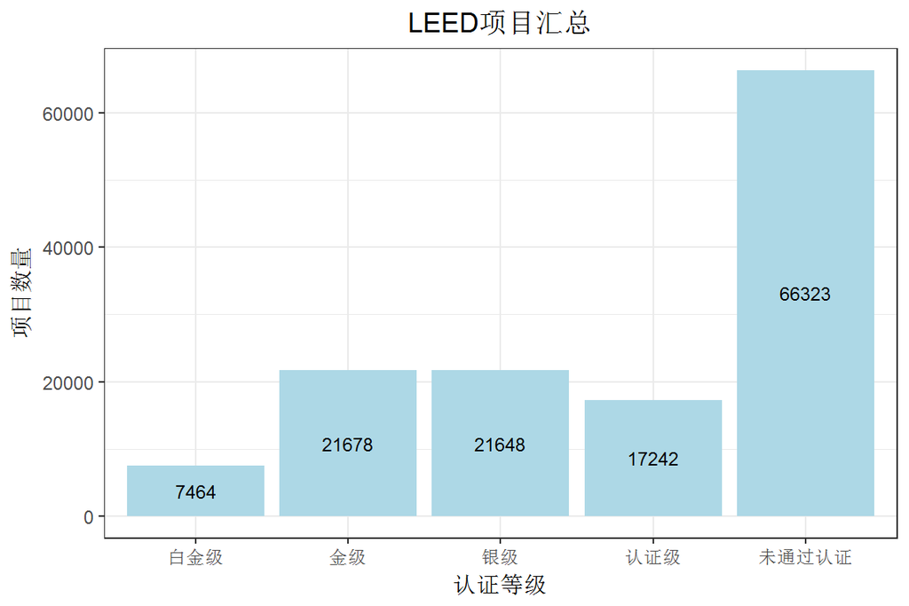

#### 注册时间与认证时间

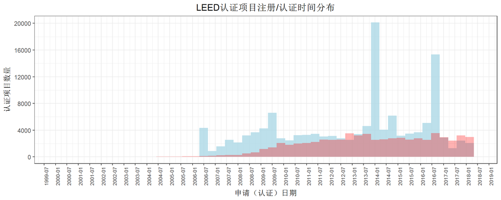

#### 认证项目版本

从最早推出的LEED认证实验性版本至今，USGBC不断的在更新LEED认证体系。认证体系按颁布的时间可分为v1~v4四个版本。此外，LEED认证体系中既包括针对不同建筑用途和使用性质加以区分的Home、School等，也包含了针对建筑不同什么周期的分类认证，如针对新建建筑的NC（New Construction）、面向既有建筑的EB（Exist Building）等。这样的设置大大增加了LEED认证的灵活性，使得不同生命周期、不同功能、不同类型的建筑都能有的放矢，取得相应的认证；但不利之处至于LEED认证叠床架屋，纷繁复杂，这一点也是LEED认证被部分业内人士所诟病的重要原因之一。  
按申请认证的版本分类LEED认证项目汇总通过认证与否的项目数量如下图所示。

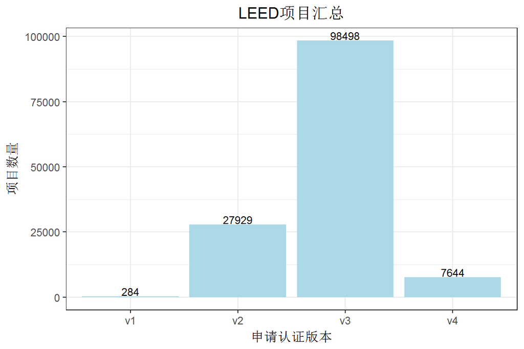

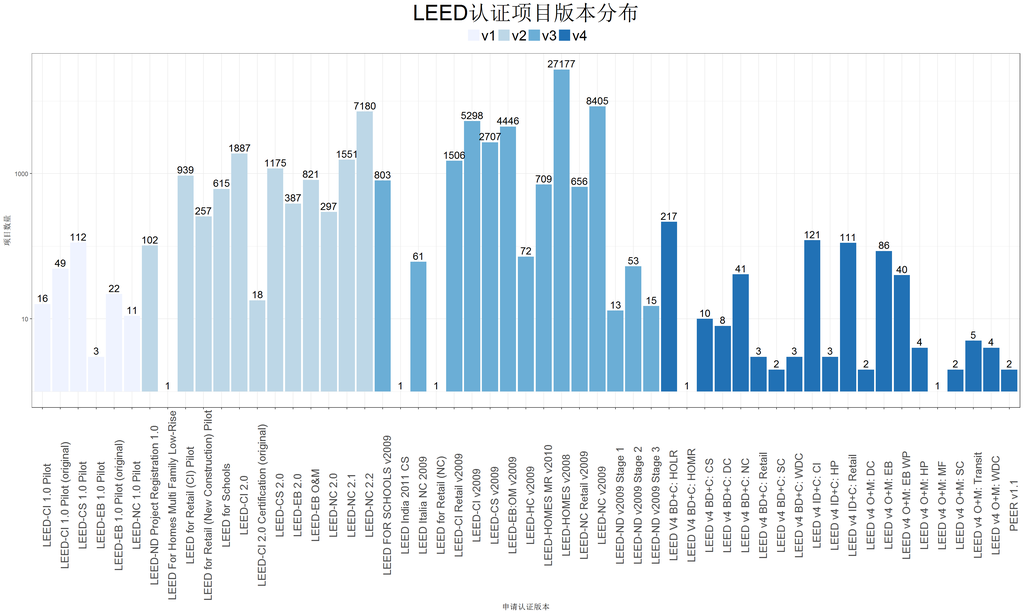

#### 认证项目建设方

源数据中**org**字段是业主单位相关信息，对申请LEED认证的项目建设单位汇总后的数据如下图所示，统计时忽略了缺失值（空字符串和NA）。从数据显示来看，申请LEED认证项目数量排名居前列的开发商（建设方）多为国际知名的大房地产企业、银行集团、商业巨头或其旗下的子公司、大等，如美国的MHI(McGuyer Homebuilders, Inc.)、富国银行（Wells Fargo Bank）、星巴克（Starbucks）等。中国大陆申请LEED认证项目的建设方中，除房地产开发企业外，可以看到，如耐克、西门子、世邦魏理仕（CBRE）、铁狮门（Tishman Speyer）等知名国际巨头，其在华的建设项目也是申请LEED认证地产的常客。

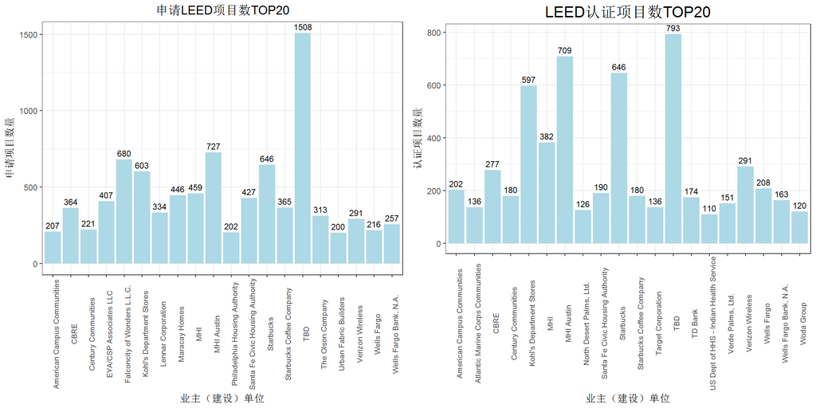

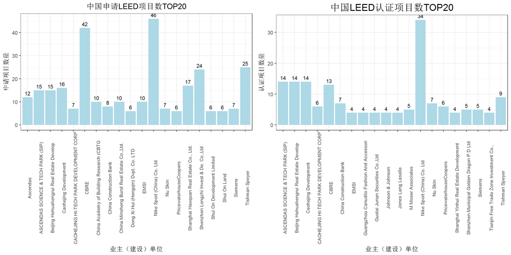

### 双变量分析

#### LEED认证版本项目项目通过率

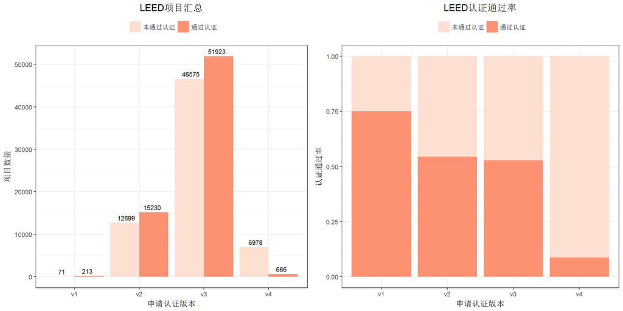

#### 获LEED认证项目认证等级与认证版本分布

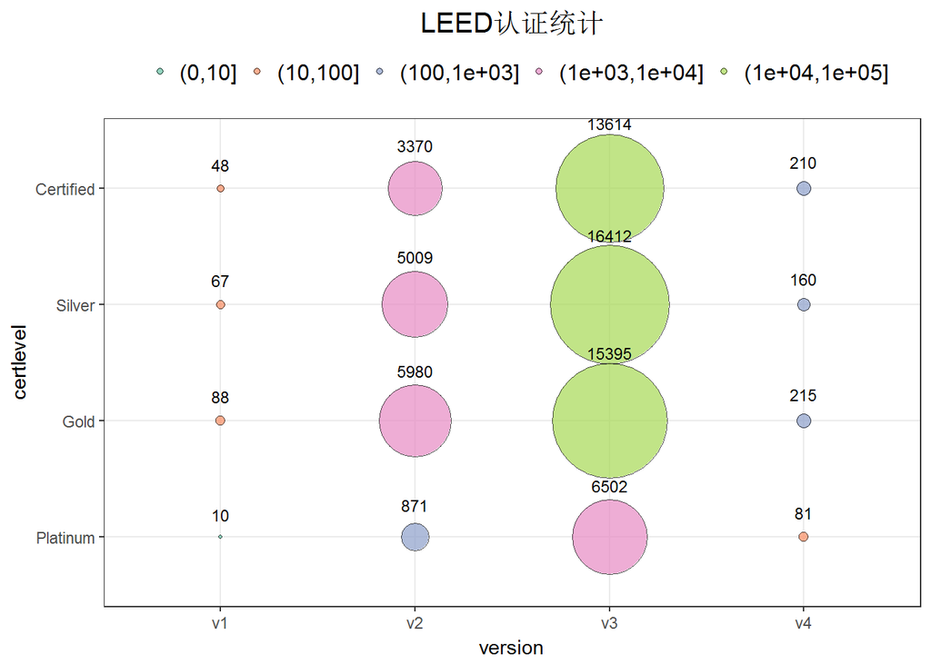

### 多变量分析

#### LEED认证项目得分分析

按照LEED认证评级规则，项目对照评级指标计算得分，再按照总分对齐认证等级进行评定。如v3、v4版本中，40～49 分为认证级、50～59 分为银级、60～79 分为金级、80～110 分为铂金级；而在此之前的版本其总得分是69分，其中认证级26-32分；银级33-38分；金级39-51分；铂金级52分以上。对所有认证项目的得分分布统计如下图所示。  
从结果来看，源数据中出现了一定数量的错误值，如v1版本认证级项目，得分接近300分。这些数据判断应为录入时的错误所致。将大于110分的所有数据作为异常值忽略后，图中仍有与LEED评分规则有出入的地方。除v4版本的得分分布中，各认证等级的项目得分界线清晰外，其它v1<sub>v3版本中均出现了不合理之处，如v3版本中的金级认证应为60</sub>79分，但按照统计结果却有不少项目得分明显超出了此区间。有可能的原因除得分录入错误之外，也有可能是是项目的**version**和**subversion**字段对应关系出错。因此有理由怀疑，源数据中的**points**字段中的错误值不在少数，后续如需对认证项目得分进行进一步分析的话，势必需先对数据清洗整理，包括核对**subversion**字段，或是利用爬虫在USGBC的项目页面中爬取相关信息。

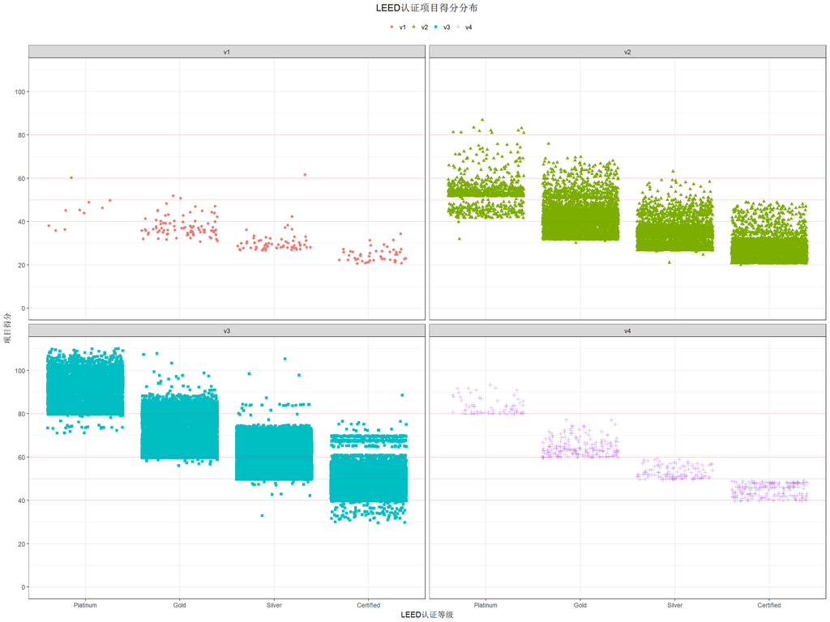

#### LEED认证项目面积数据分布

对所有认证项目的面积（totalarea与grossarea）绘制散点图，如下图所示。个人认为，这两个面积值应有一定的正相关，但从结果来看，认证项目的两个面积字段数据明显不满足相关的结论。且如图可知面积字段的数值明显偏大或偏小的异常值不少，如图中v4版本的认证项目一列所示缺失值较多，这也验证了前面缺失值分析一节的结论。

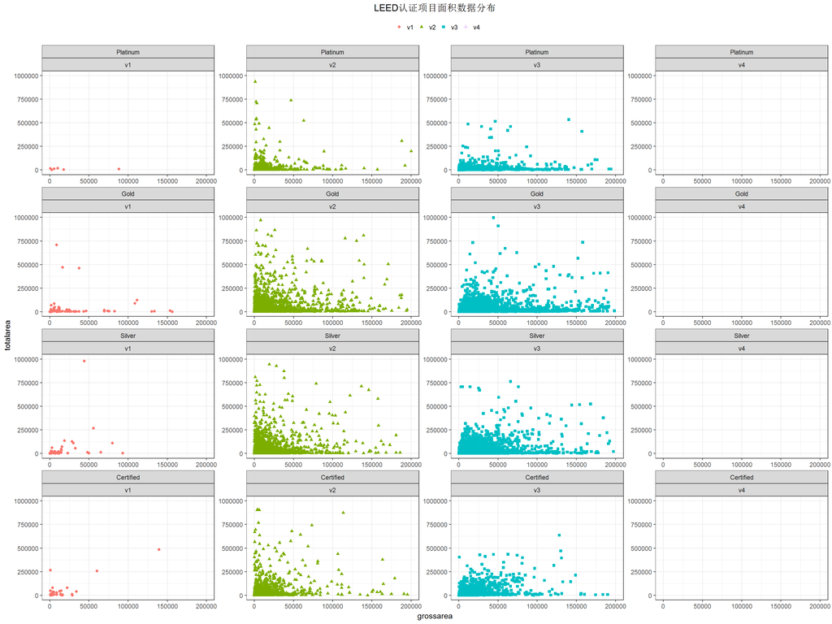

### 定稿图与总结

如前所述，初步分析数据可知，源文件数据中可信度较高的字段包括认证日期（regdate）、认证等级（certlevel）、国家/地区（country）等，而感兴趣的包括项目得分、认证版本（version和subversion）、面积（totalarea和grossarea）等均有可能存在较大误差。因此，各国申请LEED认证的逐年数据作为本次数据分析的首选。  
#### 各国LEED认证热度分析

源文件中country字段表示LEED项目所在国家，源数据中用两个大写字母来代替国家名，如US表示美国、CN表示中国。先利用正则表达式来筛选是否有不是两个大写字母的错误样本，有一条数据的country为空格字符串，其城市为Mumbai（孟买），直接将其国家改为印度（“IN”）。为便于后续分析数据，绘制地图分布数据等，将country用完整的国家名称替换。数据清理完毕后便可对LEED认证项目汇总分析。

各国LEED认证项目项目总数排名前十的国家，其申请和取得认证项目数量、认证通过率，以及认证项目在全球LEED项目中的占比如下表。

| LEED认证项目TOP10 国家 | LEED认证项目TOP10 申请项目总数 | LEED认证项目TOP10 认证项目数 | LEED认证项目TOP10 LEED项目占比 | LEED认证项目TOP10 认证通过率 |
| --- | --- | --- | --- | --- |
| United States | 110019 | 58801 | 0.864 | 0.534 |
| China | 3631 | 1344 | 0.020 | 0.370 |
| Saudi Arabia | 1225 | 856 | 0.013 | 0.699 |
| Canada | 1720 | 813 | 0.012 | 0.473 |
| India | 1623 | 619 | 0.009 | 0.381 |
| Brazil | 1300 | 490 | 0.007 | 0.377 |
| Mexico | 1022 | 347 | 0.005 | 0.340 |
| Turkey | 958 | 337 | 0.005 | 0.352 |
| United Arab Emirates | 1935 | 337 | 0.005 | 0.174 |
| Germany | 744 | 299 | 0.004 | 0.402 |

| 2015年美国以外各国LEED认证项目排名TOP10 country | 2015年美国以外各国LEED认证项目排名TOP10 USGBC公布数据 gsmofcert | 2015年美国以外各国LEED认证项目排名TOP10 USGBC公布数据 gsmofreg | 2015年美国以外各国LEED认证项目排名TOP10 USGBC公布数据 countofreg | 2015年美国以外各国LEED认证项目排名TOP10 统计汇总数据 gsmofcert | 2015年美国以外各国LEED认证项目排名TOP10 统计汇总数据 gsmofreg | 2015年美国以外各国LEED认证项目排名TOP10 统计汇总数据 tsmofcert | 2015年美国以外各国LEED认证项目排名TOP10 统计汇总数据 tsmofreg | 2015年美国以外各国LEED认证项目排名TOP10 统计汇总数据 countofreg |
| --- | --- | --- | --- | --- | --- | --- | --- | --- |
| Brazil | 5.22 | 24.50 | 991 | 8.80 | 23.17 | 13.29 | 25.01 | 929 |
| Canada | 26.63 | 63.31 | 4814 | 8.28 | 14.47 | 2.16 | 4.22 | 941 |
| China | 21.97 | 118.34 | 2022 | 49.97 | 120.27 | 20.34 | 29.82 | 2046 |
| Germany | 4.01 | 8.42 | 431 | 5.39 | 8.04 | 2.88 | 3.86 | 413 |
| India | 13.24 | 73.51 | 1883 | 7.00 | 13.53 | 3.42 | 4.87 | 654 |
| South Korea | 4.81 | 17.47 | 279 | 6.97 | 26.03 | 2.18 | 3.41 | 256 |
| Sweden | 2.54 | 4.20 | 197 | 3.33 | 4.12 | 1.20 | 1.49 | 190 |
| Taiwan | 3.84 | 9.08 | 149 | 5.73 | 8.88 | 2.25 | 3.13 | 141 |
| Turkey | 2.95 | 23.74 | 477 | 6.43 | 18.67 | 5.63 | 8.94 | 445 |
| United Arab Emirates | 3.13 | 53.44 | 910 | 4.01 | 51.51 | 9.55 | 12.30 | 881 |
| United States | 276.90 | 727.34 | 53908 | 390.97 | 757.17 | 8674.91 | 14614.19 | 82013 |

<sup>1</sup> gsmofcert: Sum of certified project’s grossarea; gsmofreg: Sum of all regiested project’s grossarea;  
<sup>2</sup> tsmofcert: Sum of certified project’s totalarea, tsmofreg: Sum of all regiested project’s totalarea;

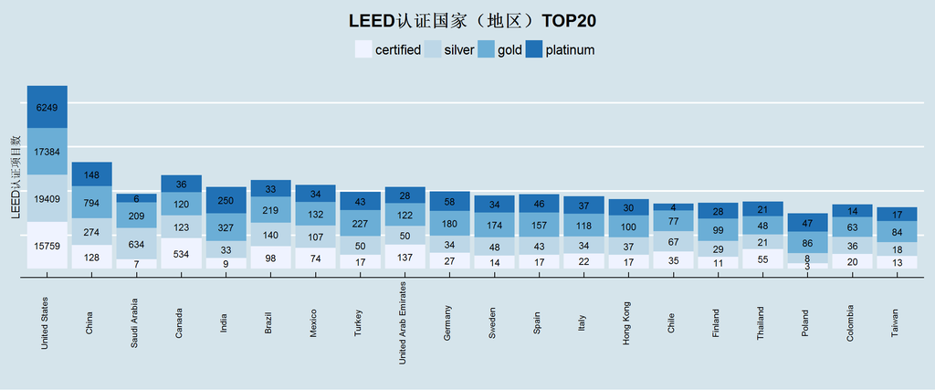

[interactive chart not shown]

各国LEED认证项目总数分布图

#### LEED认证与地区GDP相关性

作为追求全寿命周期效益最佳的绿色建筑，在带来节能降耗的同时，会带来项目初期投资的增加。从前期初步统计的汇总数据来看，可以推测LEED认证项目与GDP数据存在一定的相关性。

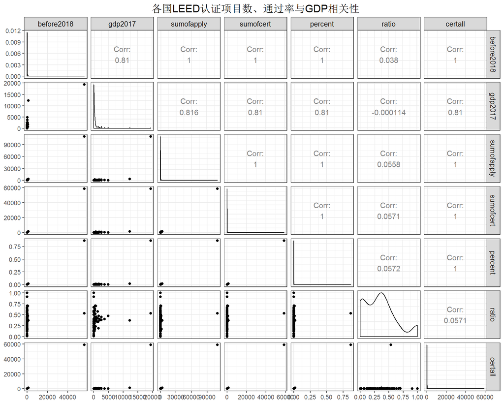

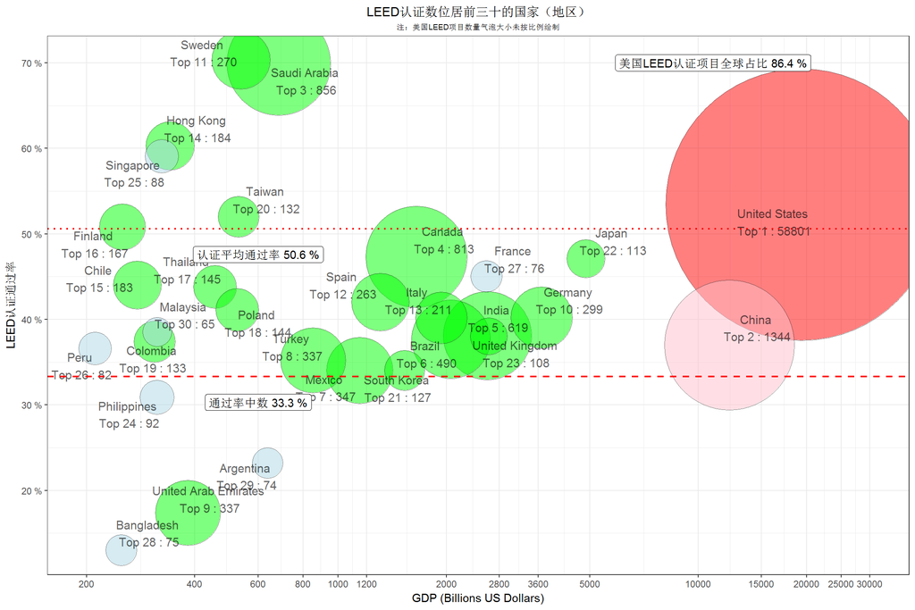

从结果分析，GDP规模与LEED认证热度（以LEED认证通过的项目数量为例）有一定的正相关性，相关系数0.81左右。但GDP排名与LEED认证项目排名并非完全一致，申请LEED认证的各国中，除美国一骑绝尘之外，排在第二的中国其GDP规模也排第二。当然，如前所述，这一统计结果与USGBC公布的数据有偏差。排在LEED申请的热度榜前列的更多的是印度、沙特、巴西等新兴经济体；GDP规模排在中国之后的经济体，日本、德国、英法等发达国家对于LEED的接受度或许并不高。究其原因，除了欧洲国家，包括日本、澳大利亚等国均有本国的节能建筑评价标准，与美国的LEED认证是竞争关系之外，纯粹以GDP经济规模数据来比较可能并不合适。如沙特、阿联酋等中东国家的房地产业发达，LEED认证项目排名靠前便容易理解。或许不采用GDP的数据而改用建筑业自身行业数据来比较LEED的认证热度，与该国的建筑工业发展规模的相关度，可能更为合理。  
从项目申请的通过率来看，在平均通过率以上的TOP30国家中，瑞典和沙特最高，其次是新加坡和香港两地；中国台湾、芬兰以及美国其通过率也超过了均值。而绝大多数国家的通过率在33~50%之间。

#### LEED认证逐年数据分析

数据中的RegDate和CertDate为申请认证的项目注册和获得认证的日期，数据中出现的最早的项目注册日期(RegDate)为“2006-05-30”，获得LEED认证的日期(CertDate)的最早日期为“2000-03-30”，貌似矛盾实则不然。RegDate的日期与USGBC于2006年开始启用LEED_Online以网络形式提交注册信息有关，在此之前的项目判断为手动录入。

根据USGBC的数据我国的LEED项目规模排在第二（*UGBI的数据是加拿大第二、中国排第三*）。作为美国的绿色建筑认证体系，LEED认证并不是我国项目建设必须强制执行的标准，而是各项目建设方（开发商）等权衡项目影响力、营销广告效应、投资增加等各种因素后的结果。且我国自己也颁布有相应的绿色建筑认证评价体系标准，即绿色建筑三星认证。因此，考虑对比LEED认证与三星认证体系在项目数量（规模），来比较二者的大陆的影响力。三星认证项目的汇总数据可以从住建部等相关数据源获取。绘制LEED认证项目逐年数据如下图所示。

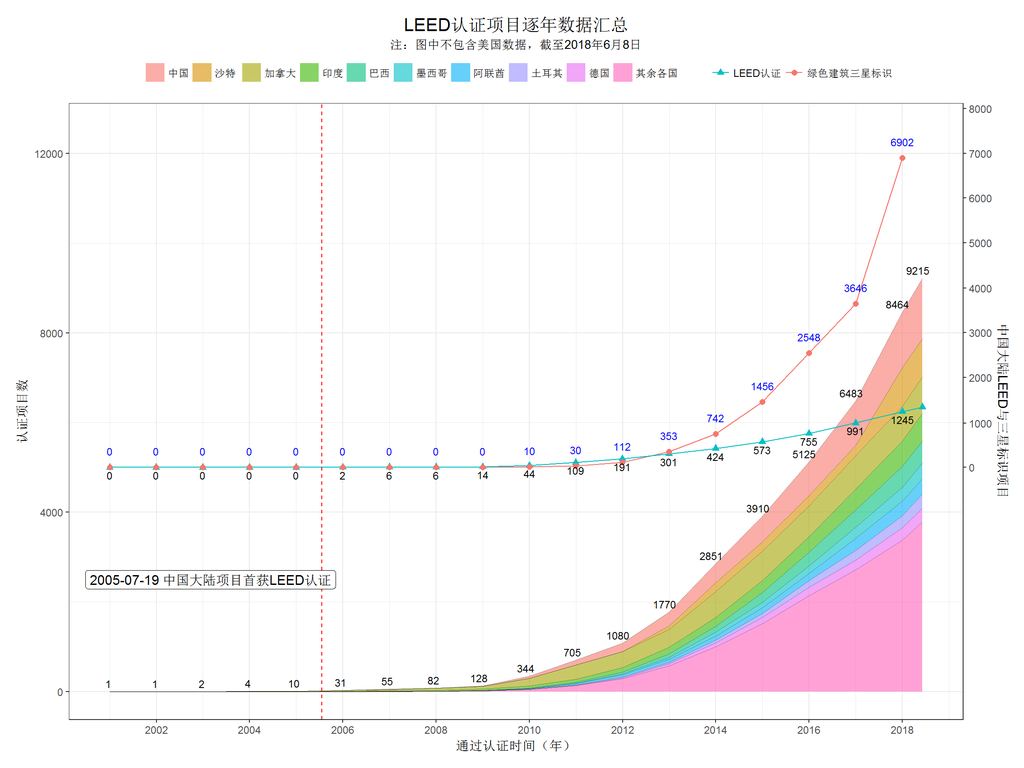

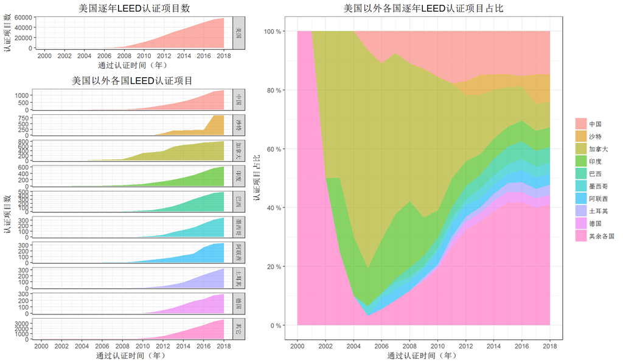

##### 结论与反思

通过此次对LEED项目的分析，体会了R语言的便捷与ggplot的强大，处理过程中的几个小经验包括：  
- 读取csv文件时设置options(stringsAsFactors = F)避免R默认将帮字符串变量转化为factor类型；csv文件中字符串如前后有空格会在筛选时造成筛选不全，需提前处理；  
- knitr:kable可以用Latex或是markdown格式显示表格格式，功能强大；  
- 利用rechart绘制地图时，遇到大意为“\u003c/ invalid utf”的字符报错，后发现是从网上复制国家名称简写表格生成countrycode.csv文件未按照UTF-8编码保存的原因。  
- 执行过程中遇到了“ input string 1 is invalid in this locale”的提示。查阅资料提及设置Sys.setlocale(locale = 1)，亦即“de_DE.UTF-8/de_DE.UTF-8/C/C/de_DE.UTF-8/de_DE.UTF-8”。但好像还是没有彻底解决，需要后续进一步摸索。  
- 美国的数据与其它国家有数量级的差异，本想利用plotrix::gap.barplot绘制不连续Y轴图形，但感觉不如ggplot强大和美观。在文中的部分图形中y轴取log10对数，如“LEED认证国家（地区）TOP20”。但y轴取了对数计算以后，分认证等级绘制柱状图的总高度会出现有变化。如统计结果沙特的认证项目数量是高于加拿大的，但柱状图上总高度却比加拿大低，因此取对数后分类型叠加会引起歧义。在“LEED认证数位居前三十的国家（地区）”图中将美国的数据进行了倍数缩放，严格意义上来说是部分图形是不够准确的。想到的最简单的方法是将美国的数据和其它各国的数据分开绘制，也许以后还会找到更好的图形化表示方法。  
源文件中的量化数据，如面积(GrossArea、TotalArea)的数值缺失较多可信度不高，而认证分数（Points）与认证等级相关。因此更多的是对LEED项目数量、等级、类别等的汇总分析。更有价值的数据分析，个人认为应该是LEED认证或是节能建筑三星标识是否对项目的增值有影响，如物业租金、住宅单位面积售价等有所助益，从提升项目附加值上来推进建筑节能的进步等，类似于“纽约市公开数据”计划中的数据分析项目。当然这需要有必要的原始数据，或许这需要将UGGBC的数据与其它部门的数据融合后才有可能。如前所述，从文件汇总统计的数据与官网发布的TOP10国家等数据有出入，有待进一步分析判断。此外，美中两国作为LEED项目数最多的两个国家，比较其各州（省）的数据，应该也可以得到一些有价值的结论，考虑在下步进一步整理分析。  
另一个直观的感受便是，我国的汇总数据，类似此次的节能建筑三星标识项目数据，其收集难度反而较美国LEED认证项目数据高出不少，甚至都无法找到权威部门发布的可信度较高的汇总数据，只能通过历年的文献中整理获得。想起以前看到的，《万历十五年》的作者黄仁宇先生曾写道中国历来不重视“数目字管理”，期待以后在这方面会有所改善吧。

###### **参考资料**

1. 维基百科楼宇面积的Floor area词条
2. [Create Awesome HTML Table with knitr::kable and kableExtra](https://cran.r-project.org/web/packages/kableExtra/vignettes/awesome_table_in_html.html)
3. [country codes](http://www.geonames.org/countries/)
4. [Sceond Y Axis](https://whatalnk.github.io/r-tips/ggplot2-secondary-y-axis.nb.html)
5. [GDP ranking (GDP)](https://datacatalog.worldbank.org/dataset/gdp-ranking)
6. [Top 10 Countries for LEED(2014)](http://plus.usgbc.org/top-10-countries/)
7. [Top 10 Countries for LEED(2015)](https://www.usgbc.org/articles/usgbc-announces-international-rankings-top-10-countries-leed-green-building)
8. [Arranging plots in a grid](https://cran.r-project.org/web/packages/cowplot/vignettes/plot_grid.html)
9. [Plot two Graphs on Same Chart R](https://stackoverflow.com/questions/23278440/plot-two-graphs-on-same-chart-r-ggplot2-parmfrow)
10. [correlograms](https://www.statmethods.net/advgraphs/correlograms.html)